# Model fitting

## Linear Models

Create some data, according to the formula
$$y(x) = x + \epsilon$$
where $\epsilon$ is normally distributed noise, with a mean of zero and a standard deviation of 2. For the sake of the example, let’s introduce a few outliers.

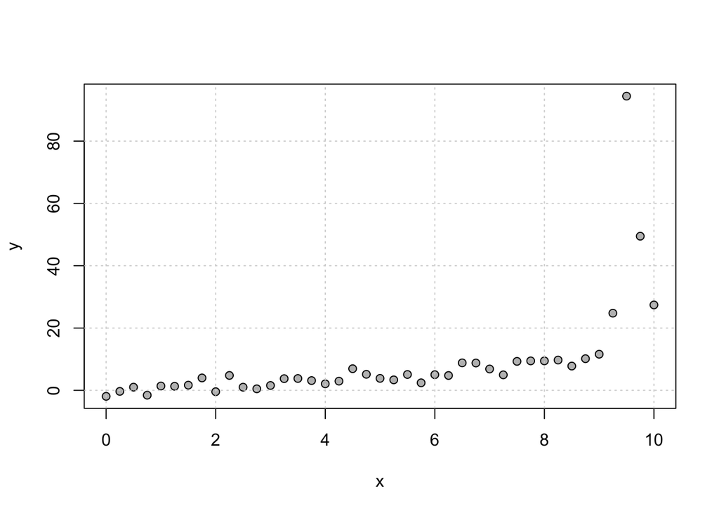

```r
set.seed(3)   # makes it reproducible
x <- seq(0, 10, 0.25)
ep <- rnorm(x, sd=2)
II <- c(38:41)
ep[II] <- abs(rnorm(II, sd=50))
y <- x + ep
plot(x, y, pch=21, bg='grey')
grid()
```

We can fit a linear model to the data, using the `lm()` function, and add it to the plot:

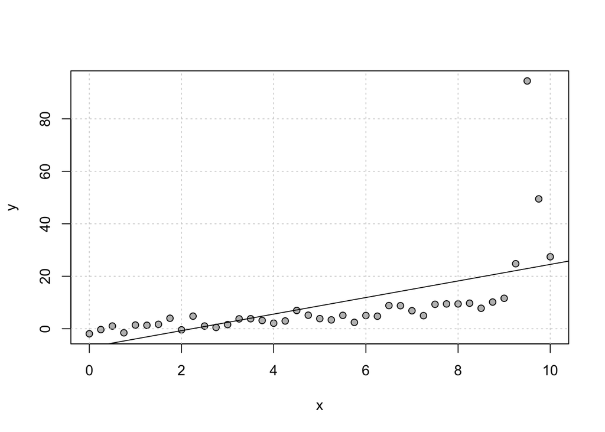

```r
m1 <- lm(y ~ x)
plot(x, y, pch=21, bg='grey')
grid()
abline(m1)
```

Note the effect that the outliers have on the inferred slope and intercept. We can get some stats about the fit examining the object returned by `lm()`, either by printing it to the screen, or by using the `summary()` function (remember, `summary()` is a generic function, and so it uses the `summary.lm()` version here):

```r
m1
```

```
##
## Call:
## lm(formula = y ~ x)
##
## Coefficients:
## (Intercept)            x
##      -7.053        3.159
```

```r
summary(m1)
```

```
##
## Call:
## lm(formula = y ~ x)
##
## Residuals:
##     Min      1Q  Median      3Q     Max
## -12.001  -7.336  -1.657   3.130  71.489
##
## Coefficients:
##             Estimate Std. Error t value Pr(>|t|)
## (Intercept)  -7.0532     4.1661  -1.693   0.0984 .
## x             3.1588     0.7171   4.405 8.02e-05 ***
## ---
## Signif. codes:  0 '***' 0.001 '**' 0.01 '*' 0.05 '.' 0.1 ' ' 1
##
## Residual standard error: 13.58 on 39 degrees of freedom
## Multiple R-squared:  0.3322, Adjusted R-squared:  0.3151
## F-statistic:  19.4 on 1 and 39 DF,  p-value: 8.018e-05
```

We can also plot the `lm` object, to get a summary of the fit using various statistical tests:

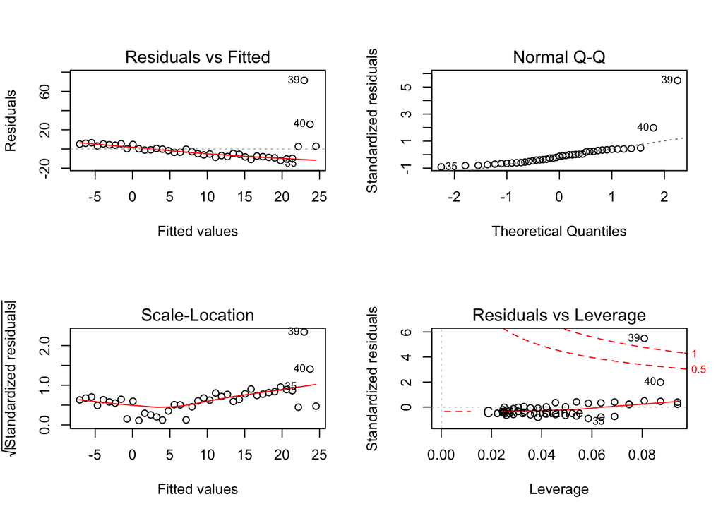

```r
par(mfrow=c(2,2))
plot(m1)
```

Clearly the outliers are strongly influencing the fit, and acting as leverage points.

One way of doing a regression in the presence of outliers and leverage points is to use a “robust linear model” with the `rlm()` function. See `?rlm` for more details, but let’s see what effect it has on our synthetic data:

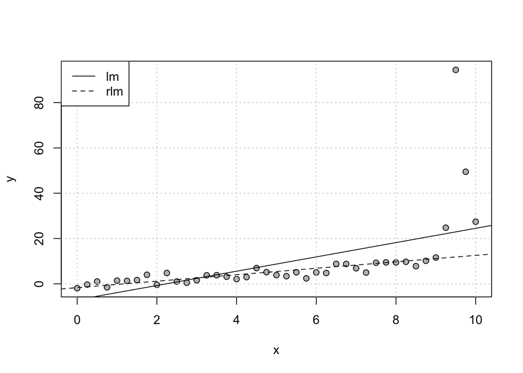

```r
library(MASS)
m2 <- rlm(y ~ x)
par(mfrow=c(1,1))
plot(x, y, pch=21, bg='grey')
grid()
abline(m1)
abline(m2, lty=2)
legend('topleft', c('lm', 'rlm'), lty=1:2)
```

And we can similarly plot the results of the regression:

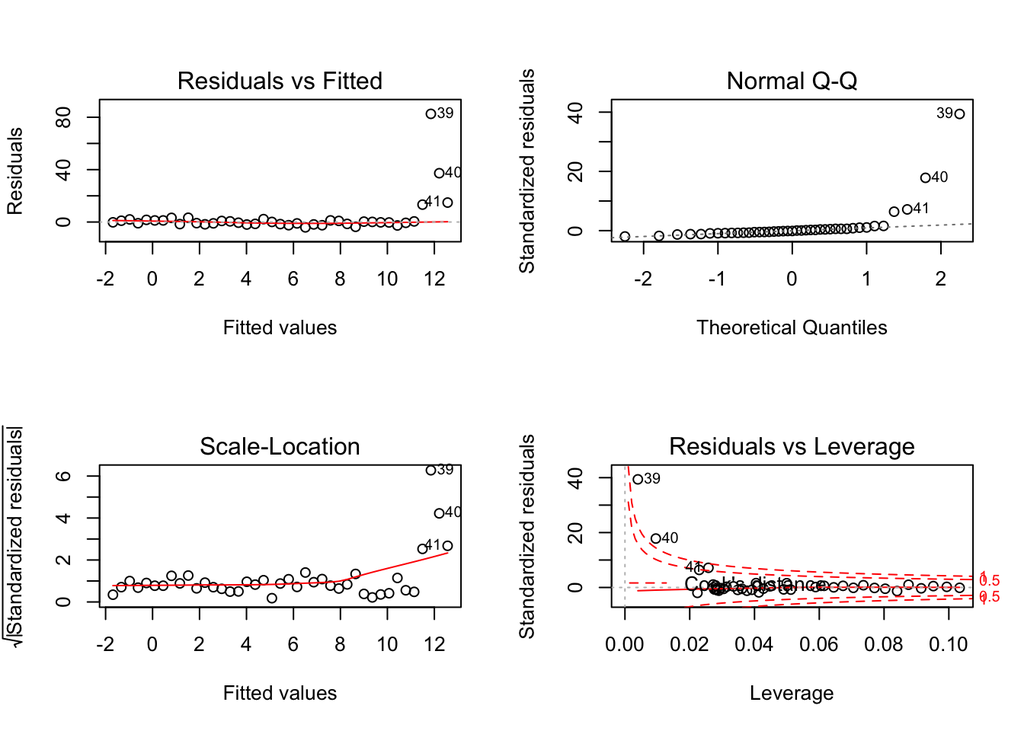

```r
par(mfrow=c(2,2))
plot(m2)
```

Notice that the residuals no longer have a significant trend (panel 1), and that the leverage of the outliers is significantly reduce (panel 4).

## Polynomial fits

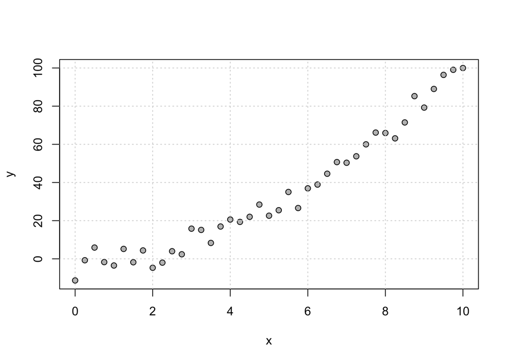

```r
par(mfrow=c(1,1))
x <- seq(0, 10, 0.25)
ep <- rnorm(x, sd=5)
y <- x^2 + ep
plot(x, y, pch=21, bg='grey')
grid()
```

Now we make another call to `lm()`:

```r
m3 <- lm(y ~ I(x^2))
summary(m3)
```

```
##
## Call:
## lm(formula = y ~ I(x^2))
##
## Residuals:
##      Min       1Q   Median       3Q      Max
## -10.0964  -3.1966   0.3464   3.3892   7.5876
##
## Coefficients:
##             Estimate Std. Error t value Pr(>|t|)
## (Intercept) -1.23065    1.02172  -1.204    0.236
## I(x^2)       1.05042    0.02243  46.834   <2e-16 ***
## ---
## Signif. codes:  0 '***' 0.001 '**' 0.01 '*' 0.05 '.' 0.1 ' ' 1
##
## Residual standard error: 4.394 on 39 degrees of freedom
## Multiple R-squared:  0.9825, Adjusted R-squared:  0.9821
## F-statistic:  2193 on 1 and 39 DF,  p-value: < 2.2e-16
```

Note the use of the `I()` construct in the `formula` argument for `lm()`. See `?formula` for more details about the syntax of formulas, but basically it ensures that we do the fit against the *square* of x.

Another way to do this, that I just learned from [stack overflow](http://stackoverflow.com/questions/3822535/fitting-polynomial-model-to-data-in-r) is to use the `poly()` function:

```r
mpoly2 <- lm(y ~ poly(x, 2))
summary(mpoly2)
```

```
##
## Call:
## lm(formula = y ~ poly(x, 2))
##
## Residuals:
##     Min      1Q  Median      3Q     Max
## -7.8711 -3.0769  0.3198  3.2693  8.5359
##
## Coefficients:
##             Estimate Std. Error t value Pr(>|t|)
## (Intercept)   34.221      0.679   50.40  < 2e-16 ***
## poly(x, 2)1  200.461      4.348   46.10  < 2e-16 ***
## poly(x, 2)2   46.905      4.348   10.79 3.98e-13 ***
## ---
## Signif. codes:  0 '***' 0.001 '**' 0.01 '*' 0.05 '.' 0.1 ' ' 1
##
## Residual standard error: 4.348 on 38 degrees of freedom
## Multiple R-squared:  0.9833, Adjusted R-squared:  0.9825
## F-statistic:  1121 on 2 and 38 DF,  p-value: < 2.2e-16
```

Since `abline()` won’t work for this model, we now use `predict()` to plot the results:

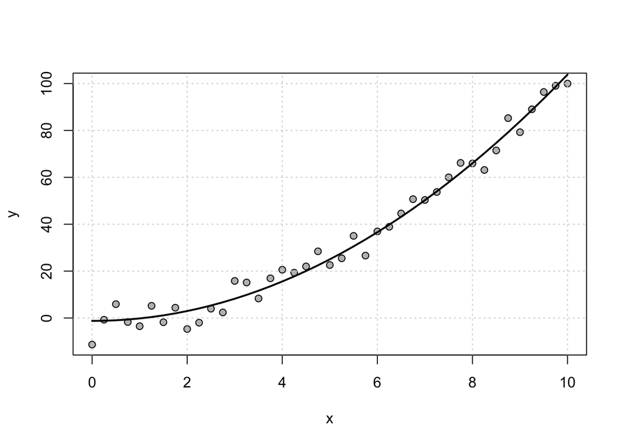

```r
y.pred <- predict(m3)
plot(x, y, pch=21, bg='grey')
grid()
lines(x, y.pred, lwd=2)
```

Unless told otherwise, predict will return predicted values for `y` at the original `x` locations.

We can use the `confint()` function to get an idea of the 95% confidence limits for the fit:

```r
confint(m3)
```

```
##                 2.5 %    97.5 %
## (Intercept) -3.297282 0.8359819
## I(x^2)       1.005056 1.0957889
```

and we can add them to the plot by specifying the `interval="confidence"` argument in `predict()`. Note that `predict()` now returns a 3-column matrix:

```r
y.pred <- predict(m3, interval = 'confidence')
str(y.pred)
```

```
##  num [1:41, 1:3] -1.231 -1.165 -0.968 -0.64 -0.18 ...
##  - attr(*, "dimnames")=List of 2
##   ..$ : chr [1:41] "1" "2" "3" "4" ...
##   ..$ : chr [1:3] "fit" "lwr" "upr"
```

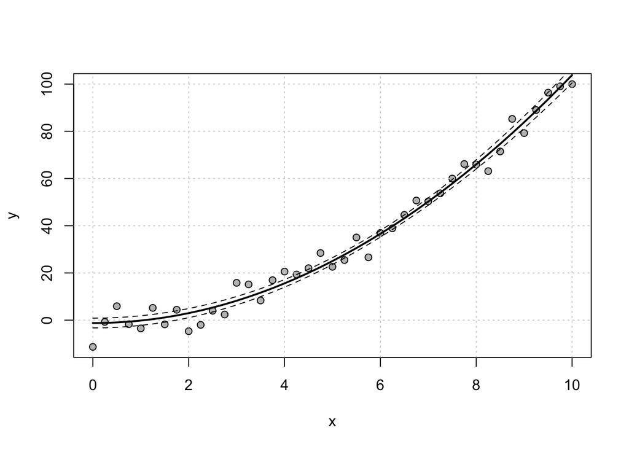

```r
plot(x, y, pch=21, bg='grey')
grid()
lines(x, y.pred[,1], lwd=2)
lines(x, y.pred[,2], lty=2)
lines(x, y.pred[,3], lty=2)
```